# Appendix to *Measuring Children’s Early Vocabulary in Low-Resource Languages Using a Swadesh-style Word List*

[redacted for anonymous review]

June 20, 2025

## Unilemma Operationalisation and Updating

Unilemmas are rough cross-linguistic conceptual mappings for words. For example, “dog” (English), “perro” (Spanish), and “chien” (French) all seem like they describe the same concept, *dog*. We thus have *dog* as the unilemma for this concept, allowing mapping between different forms in different languages.

Decisions about which words correspond to which unilemmas are necessarily somewhat arbitrary. Our design intention for unilemmas was to provide reasonable mappings, lumping together many meanings rather than splitting them, allowing us to build predictive models of cross-linguistic similarities and differences in acquisition. If we split the conceptual world too finely, it would be difficult to understand how similar the information sources are; if we split too coarsely, we can at least discover that languages differ by the differences in predictors.

However, we also preserve distinctions for concepts that are *prima facie* similar, but that play very different cultural roles. For example, although “pan” (Spanish) and “tortilla” (Mexican Spanish[^1]) are relatively similar, they play different cultural roles in Mexican Spanish, and hence we err towards splitting these into separate categories.

There remained other issues regarding unilemma definitions, including cases of polysemy, handling syntactic categories, and pronouns; in each case, we made decisions based on our best guess of the most basic or common interpretation in the child language context. Further details can be found in our unilemma policy document, available at https://github.com/langcog/update_unilemmas/blob/main/unilemma_policy.md.

We then recruited native or advanced proficient speakers of all the languages in Wordbank to help verify and correct unilemmas for the CDI forms. Subsequently, two of the authors (GK, AWMT) reviewed the suggestions and made decisions about conflicts, and standardized unilemmas into a canonical form across all instruments. More details about the recent update can be found at https://github.com/langcog/update_unilemmas.

## Word Difficulty by Semantic Category and Language

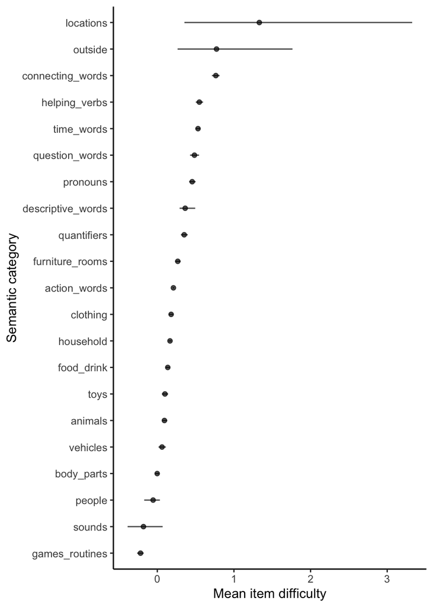

Mean difficulty of CDI words by semantic category. Bars represent bootstrapped 95% confidence intervals.

## Cross-linguistic similarities

We look at the Spearman correlation between the item difficulty of each language compared to each other language. We might expect this to recapitulate the historical relationship between languages, with more similar languages having more similar item difficulties (e.g., Quebecois and European French).

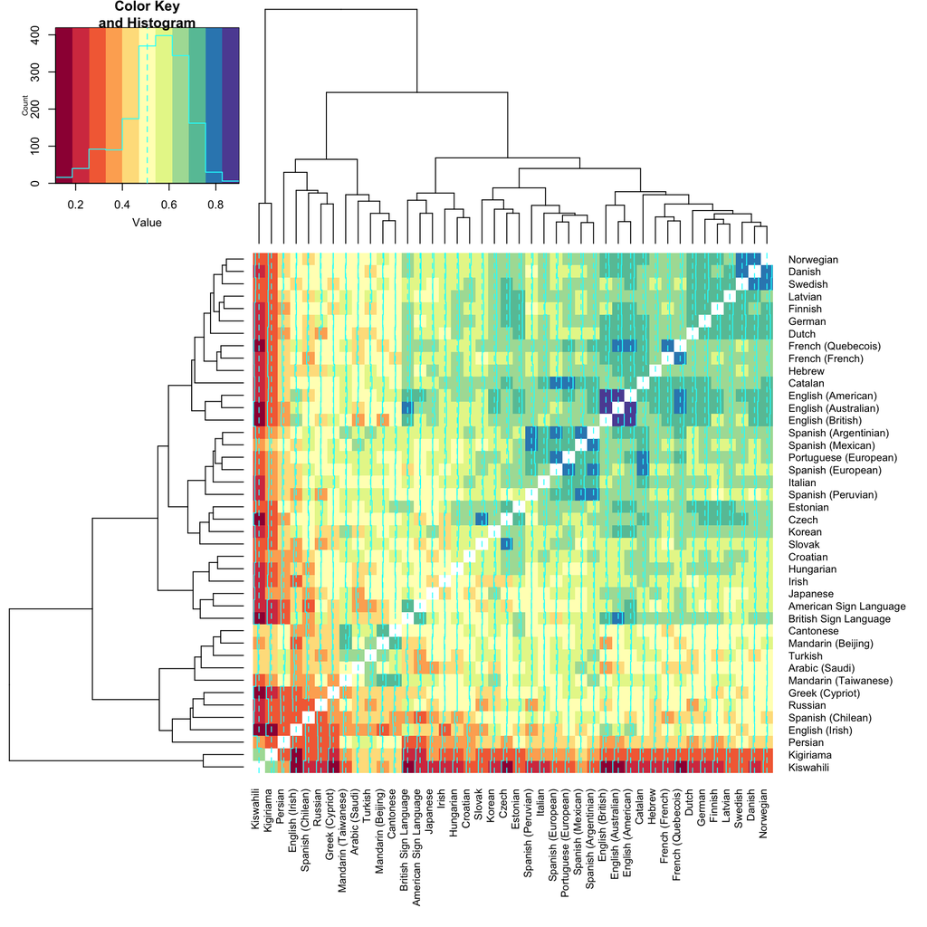

Cross-linguistic similarity (Spearman correlation) of IRT item difficulty from the CDI.

# Cross-validation Results

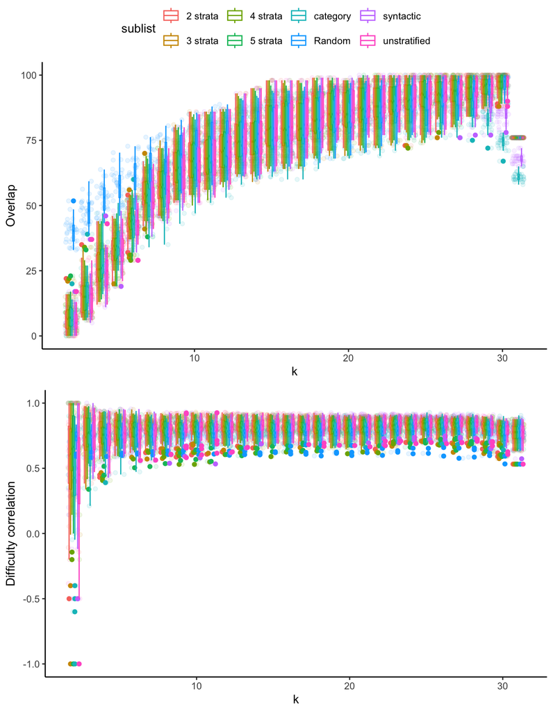

Difficulty correlation and overlap by k for the different sublist selection methods.

## Swadesh CDI vs. Full CDI:WS

The table below shows the correlation between full CDI and Swadesh-CDI for syntactic category stratification method, for items on at least $k=27$ CDIs, for each of the 32 languages that the IRT models were trained on.

Swadesh CDI vs. Full CDI scores for 32 training languages.

| k | Language | Overlap | Full vs. S-CDI r |
| --- | --- | --- | --- |
| 27 | Arabic (Saudi) | 95 | 0.966 |
| 27 | Cantonese | 90 | 0.986 |
| 27 | Catalan | 93 | 0.989 |
| 27 | Croatian | 97 | 0.992 |
| 27 | Czech | 94 | 0.988 |
| 27 | Danish | 99 | 0.992 |
| 27 | Dutch | 98 | 0.965 |
| 27 | English (American) | 98 | 0.989 |
| 27 | English (Australian) | 76 | 0.990 |
| 27 | English (British) | 90 | 0.929 |
| 27 | Estonian | 93 | 0.990 |
| 27 | Finnish | 95 | 0.944 |
| 27 | French (French) | 97 | 0.973 |
| 27 | French (Quebecois) | 98 | 0.985 |
| 27 | German | 90 | 0.991 |
| 27 | Hebrew | 87 | 0.980 |
| 27 | Hungarian | 96 | 0.989 |
| 27 | Italian | 97 | 0.991 |
| 27 | Japanese | 86 | 0.986 |
| 27 | Korean | 87 | 0.986 |
| 27 | Latvian | 96 | 0.989 |
| 27 | Mandarin (Beijing) | 92 | 0.988 |
| 27 | Mandarin (Taiwanese) | 88 | 0.991 |
| 27 | Norwegian | 97 | 0.992 |
| 27 | Portuguese (European) | 91 | 0.988 |
| 27 | Russian | 89 | 0.987 |
| 27 | Slovak | 84 | 0.988 |
| 27 | Spanish (Argentinian) | 96 | 0.984 |
| 27 | Spanish (European) | 84 | 0.986 |
| 27 | Spanish (Mexican) | 94 | 0.988 |
| 27 | Swedish | 96 | 0.985 |
| 27 | Turkish | 87 | 0.990 |

### Generalization Test

Comparison to the 10 low-data languages. Note that many proposed Swadesh items are not actually on the CDI:WS forms available to test generalization.

Swadesh CDI vs. Full CDI:WS scores for 10 generalization languages.

| language | 2 strata | Random | S-CDI110 | category | syntactic | unstratified |
| --- | --- | --- | --- | --- | --- | --- |
| American Sign Language | 0.975 | 0.984 | 0.978 | 0.982 | 0.976 | 0.974 |
| British Sign Language | 0.989 | 0.991 | 0.990 | 0.989 | 0.990 | 0.989 |
| English (Irish) | 0.974 | 0.976 | 0.968 | 0.973 | 0.964 | 0.967 |
| Greek (Cypriot) | 0.979 | 0.988 | 0.987 | 0.991 | 0.985 | 0.979 |
| Irish | 0.977 | 0.985 | 0.983 | 0.988 | 0.980 | 0.974 |
| Kigiriama | 0.965 | 0.932 | 0.962 | 0.934 | 0.964 | 0.962 |
| Kiswahili | 0.979 | 0.980 | 0.986 | 0.988 | 0.985 | 0.976 |
| Persian | 0.954 | 0.948 | 0.957 | 0.955 | 0.957 | 0.958 |
| Spanish (Chilean) | 0.966 | 0.907 | 0.970 | 0.900 | 0.968 | 0.969 |
| Spanish (Peruvian) | 0.979 | 0.966 | 0.983 | 0.956 | 0.980 | 0.957 |

## Swadesh-CDI Items

Below we show the full list of 100 Swadesh CDI unilemmas, along with their average cross-linguistic difficulty (d_m), variability in difficulty (d_sd), number of CDI:WS forms they appear on (n, out of 32), semantic category, and lexical category. The semantic and lexical categories are based on American English, as unilemmas sometimes appear in different categories on different forms, as appropriate.

|  | uni_lemma | num_langs | mean_d | sd_d | semantic_category | syntactic_category |
| --- | --- | --- | --- | --- | --- | --- |
| 1 | eat | 32 | 1.091178384801449 | 1.009265606474688 | action_words | predicates |
| 2 | sit | 31 | 0.6174995592067452 | 1.126784752007156 | action_words | predicates |
| 3 | cry | 32 | -0.06898251130037228 | 1.106103611495308 | action_words | predicates |
| 4 | jump | 31 | -0.1179296520943223 | 1.127709446391087 | action_words | predicates |
| 5 | dance | 31 | -0.1187645336519595 | 0.978633262295574 | action_words | predicates |
| 6 | fall | 32 | -0.143840393452877 | 1.026885854967222 | action_words | predicates |
| 7 | sing | 32 | -0.4115102047964757 | 1.061555207471053 | action_words | predicates |
| 8 | blow | 29 | -0.7748922848159107 | 1.129092338291541 | action_words | predicates |
| 9 | help | 30 | -0.9031755298740674 | 1.090055691841331 | action_words | predicates |
| 10 | wait | 32 | -1.306179575365009 | 1.133731858085965 | action_words | predicates |

[output cut: 90 more lines]

## Comparison of Swadesh CDI Items to Other Lists

```
## [1] "nose"          "fish (animal)" "tree"
```

```
## [1] "what" "big"  "tree" "nose" "hot"  "cold"
```

```
##  [1] "what"             "mommy"            "airplane"         "milk"
##  [5] "lion"             "nose"             "elephant"         "cold"
##  [9] "dirty"            "hot"              "where (question)"
```

[^1]: Note that “tortilla” in European Spanish refers not to flatbread, but to an egg and potato omelette.